# Packages, I/O, & Functions

## Packages

Yesterday, we kept everything in `base` R. However, R has 18045 `packages` and grows by the day.

Fortunately R doesn’t come with every package already installed; instead, it comes with a small set of packages that can do everything you would ever want to do. While the power is infinite, time is not. Since R (Python and Julia, too) is an open-source language, people have contributed packages back to the community. The vast majority of these packages will not be necessary for you.

The Comprehensive R Archive Network (CRAN) holds all of the “official” R packages, with more hosted on GitHub and Bioconductor.

For a nicer breakdown of what packages are out there and what they do, you can check out the [CRAN Task Views](https://cloud.r-project.org/web/views/).

Let’s say that we are interested in visualizing some relationships. That’s great, R comes with tons of base plots:

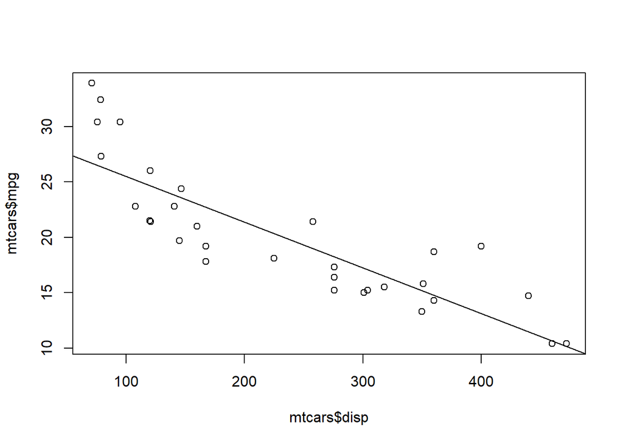

```r
plot(mtcars$disp, mtcars$mpg)
abline(lm(mpg ~ disp, data = mtcars))
```

Altogether, not terribly difficult. Creating such a simple plot, though, required 3 total functions and nothing in `abline` is friendly. Many people have solved the plotting problem and implemented better solutions in their own packages.

Let’s install 2 packages:

```r
install.packages(c("car", "ggplot2"))
```

These packages have been downloaded to our machines, but they are not ready to use. We have to make them accessible to our global environment and we do that with `library`:

```r
library(car)
```

Using library loads the entire package. If I just want to use 1 function from a package, I could also do this:

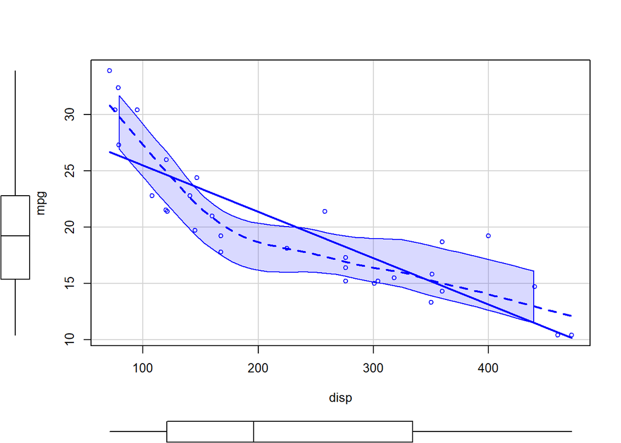

```r
car::scatterplot(mpg ~ disp,
            data = mtcars)
```

Not bad, but that is a little messy for my taste. If I want to tweak this visualization, how might I do it?

While this is fine, it is far the vanguard of statistical visualization. Instead, we should use `ggplot2`.

```r
library(ggplot2)
```

We can construct the same scatterplot:

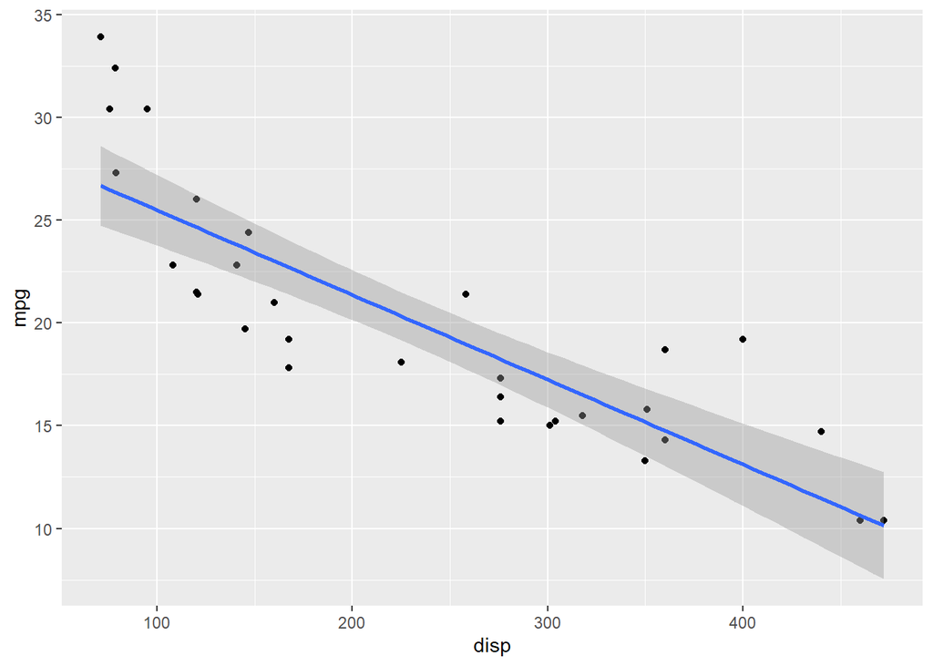

```r
ggplot(data = mtcars,
       mapping = aes(x = disp, y = mpg)) +
  geom_point() +
  geom_smooth(method = "lm")
```

```r
install.packages('plotly')
```

## The Ins and Outs

### The Humble CSV

The comma-separated value (csv) file is the most common way that you will move data around for R. They are nothing more than text files, with some specific formatting. The great thing about a csv is that it is both human readable and human editable (though you probably don’t want to get into the business of editing one by hand). There are many ways to read a csv file into R:

```r
st_joe_land <- read.delim(file = "stJoeLand.csv", sep = ",")

st_joe_land <- read.csv(file = "stJoeLand.csv")
```

Both of those will return the exact same result!

Nothing too fancy is required for a `read.csv` – R won’t perform any magic on the variables, but it will coerce the variable names into valid R names. It won’t mess up your variables and it behaves as you would expect it to.

A major gripe against `read.csv` is that it is slow and people get annoyed with the variable name changes. A few packages have gotten around those limitations:

```r
install.packages(c("readr", "data.table"))
```

Let’s try those out:

```r
st_joe_land_readr <- readr::read_csv(file = "stJoeLand.csv")

st_joe_land_datatable <- data.table::fread(input = "stJoeLand.csv")
```

I tend to opt towards data.table for my reading.

Changing names is easy enough, so always feel inclined to handle things you want to rename:

```r
names(st_joe_land_datatable)[names(st_joe_land_datatable) == "Zip Code"] <-
  "Zip_Code"
```

### Excel

People will send you an Excel file…you don’t have to be friends with them, but you should still be kind to them.

```r
install.packages("readxl")
```

And now:

```r
st_joe_land_excel <- readxl::read_excel(path = "stJoeLand.xlsx")
```

### R Data

As you progress through classes, you will need to make good friends with `save` and `load`.

You can save any R objects like this:

```r
save(st_joe_land, st_joe_land_datatable, file = "stJoeInfo.RData")
```

You can then load that saved data back into R:

```r
load("stJoeInfo.RData")
```

So…why would you want to do this?

Let’s string some stuff together. First, try to use the aggregate function (going all the way back to yesterday) to get the average sale prices across the school districts – which has the highest average sale price?

Now, create a visualization. First, though, try seeing which school district has the most houses in this data:

```r
summary(as.factor(st_joe_land$school_district))
```

```
   JG   MSC   NPU   PHM SBCSC
    2    30     4    58   156
```

Subset your data down to only contain houses within that school district and visualize the relationship between sale price and any other numeric variable.

## What Is A Function?

We just used a bunch of functions that other people have written and there is nothing wrong with that – we all stand on the shoulders of giants!

A function is nothing more than an object – but it is an object that acts upon another object!

We’ve already used functions that R has built into it and functions that come in other packages, but let’s write our own.

We are going to do something really easy: let’s describe how to calculate an arithmetic mean.

```r
my_mean <- function(numbers) {
  # The length function gives the length
  # of a vector. Use nrow for number of
  # rows in a data.frame.
  numbers_length <- length(numbers)
  numbers_sum <- sum(numbers)
  numbers_average <- numbers_sum / numbers_length
  # The return function isn't strictly necessary,
  # but it is a safe way of handling this. You could
  # also just put numbers_average at the end and
  # it would print out.
  return(numbers_average)
}

my_mean(st_joe_land$sale_price)
```

```
[1] 150563.4
```

Let’s see if we can make something else, but with a few more arguments.

```r
mean_scaler <- function(numbers, center = TRUE) {
  if(center == TRUE) {
    result <- my_mean(numbers - my_mean(numbers))
  } else result <- my_mean(numbers)
  return(result)
}
```

```r
apply(X = st_joe_land[, c("sale_price", "year_built")],
      MARGIN = 2,
      FUN = mean)
```

```
sale_price year_built
 150563.44    1967.11
```

```r
colMeans(st_joe_land[, c("sale_price", "year_built")])
```

```
sale_price year_built
 150563.44    1967.11
```